# Gibbs Sampling

February 22, 2020, Updated 2020-10-07

## Bivariate normal distribution

- Consider a single observation \((y_1,y_2)\) from a bivariate normally distributed population with unknown mean \((\theta_1,\theta_2)\) and known covariance matrix \((1, \rho ; \rho 1)\).
- With a uniform prior distribution on \(\theta\), the posterior distribution is:

\[ \begin{bmatrix} \theta_1\\ \theta_2 \end{bmatrix} | y \sim N( \begin{bmatrix} y_1\\ y_2 \end{bmatrix} , \begin{bmatrix} 1 & \rho \\ \rho & 1 \end{bmatrix} ) \]

## Gibbs

- Although it’s posisble to draw directly from the joint posterior of \((\theta_1,\theta_2)\), we demonstrate the Gibbs sampler here for the purpose of exposition.
- We can calculate the conditional distributions as: \[ (\theta_1 \mid \theta_2, y) \sim N(y_1 + \rho(\theta_2 - y_2), 1- \rho^2) \\ (\theta_2 \mid \theta_1, y) \sim N(y_2 + \rho(\theta_1 - y_1), 1- \rho^2) \]

## Gibbs sampler in R

- First write the gibbs sampler function:

```r
binorm_gibbs<- function(theta_init, y, rho, niter){
  theta = matrix(0,2,niter)
  theta[1,] = theta_init
  for(i in 2:niter){
    theta[1,i] = rnorm(1,y[1]+rho*(theta[2,(i-1)]-y[2]),1-rho^2)
    theta[2,i] = rnorm(1,y[2]+rho*(theta[1,i]-y[1]),1-rho^2) ## theta_(i,1) updated
  }
  return(theta)
}
```

## Gibbs sampler in R

Fix value of \(y\), initial \(\theta\), correlation \(\rho\) and `niter`.

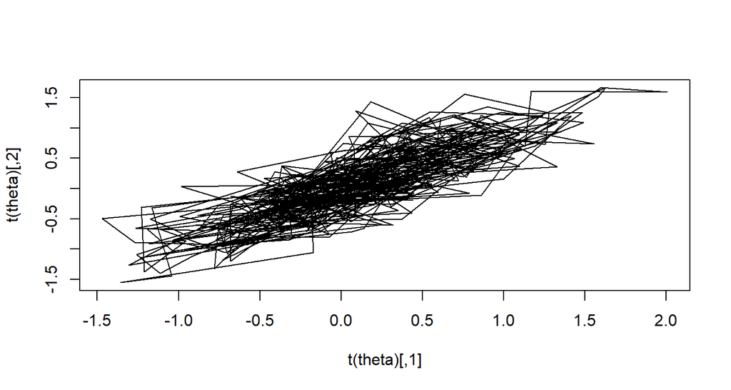

```r
y = c(0,0); theta_init = y; niter = 500; rho = 0.8
theta <- binorm_gibbs(theta_init,y,rho,niter)
plot(t(theta),type="l")
```

## Better plot

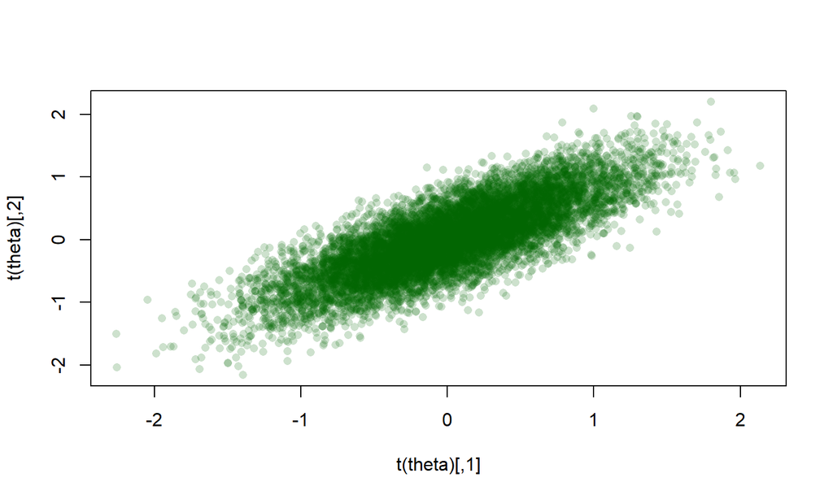

```r
theta <- binorm_gibbs(theta_init,y,rho,niter=1e4)
plot(t(theta), col=rgb(0,100,0,50,maxColorValue=255), pch=16)
```

## Normal hierarchical model

\[ y_i \stackrel{\text{IID}}{\sim} N(\mu, \sigma^2), i = 1, \ldots, n \\ \pi(\mu, \sigma^2) \propto \frac{1}{\sigma^2} \; \text{(Jeffreys prior)} \]

- This is a conjugate prior, i.e. we can calculate the posterior of \(\mu\) and \(\sigma\) easily and they will be easy to sample from.

## Joint density

\[ \begin{align*} p(\mu, \sigma^2 \mid y_1, \ldots, y_n) & = \prod_{i=1}^{n}\left( \frac{1}{\sqrt{2\pi\sigma^2}}\exp\left(-\frac{(y_i-\mu)^2}{2\sigma^2}\right) \right) \times \frac{1}{\sigma^2} \\ & \propto (\frac{1}{\sigma^2})^{n/2+1} \exp\left(-\frac{1}{\sigma^2} \frac{\sum_{i=1}^n (y_i -\mu)^2}{2} \right) \end{align*} \]

- This is enough.
- We can see \(1/\sigma^2\) looks like a Gamma and \(\mu\) looks like a Gaussian.

## Full conditionals

We also know the full conditionals: \[ \begin{align*} \pi(\mu \mid \sigma^2, y) & = N(\bar{y}, \sigma^2/n) \\ \pi(\tau^2 \mid \mu, y) & = \text{Gamma}(\frac{n}{2}, \frac{1}{2} \sum_{i=1}^{n} (y_i - \mu)^2 ) \text{ where } \tau = \sigma^{-2} \end{align*} \]

## Gibbs Sampling in R

Sampling from the full conditionals is easy in R.

```r
normal_gibbs<- function(y, niter, mu0 = mean(y), sigma0 = var(y)){
  n = length(y)
  mu = rep(mu0,niter);sigmasq = rep(sigma0,niter)

  ## initialize
  mu[1] = mu0; sigmasq[1] = sigma0;

  for(i in 2:niter){
    tau = rgamma(1,shape=n/2,rate=0.5*sum((y-mu[i-1])^2))
    sigmasq[i] = 1/tau
    mu[i] = rnorm(1,mean(y), sigmasq[i]/n)
    }
  return(list(mu=mu, sigmasq = sigmasq))
}
```

## Running Gibbs

```r
m = 2
s = 4
y = rnorm(100,m,s)
nmc = 1000
burn = 1000
gibbs.fit <- normal_gibbs(y,niter = nmc+burn, mu0 = 0, sigma0 = 1)
summary(gibbs.fit$mu[(burn+1):(burn+nmc)])
```

```
##    Min. 1st Qu.  Median    Mean 3rd Qu.    Max.
##   1.150   1.849   1.971   1.976   2.103   2.628
```

```r
summary(gibbs.fit$sigmasq[(burn+1):(burn+nmc)])
```

```
##    Min. 1st Qu.  Median    Mean 3rd Qu.    Max.
##   12.27   17.57   19.17   19.51   21.19   29.98
```

## Multiple chains

We plot the entire Markov chains for two different starting values for a small number of iterations to show how fast the two chains will become indistinguishable.

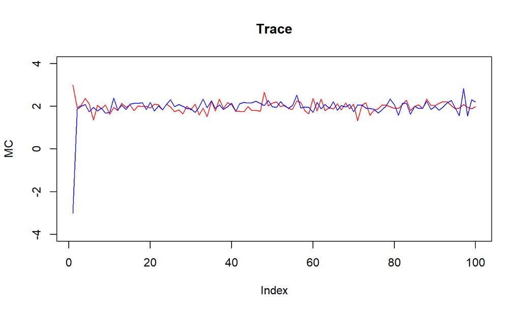

```r
plot(normal_gibbs(y,niter = 100, mu0 = 3, sigma0 = 1)$mu, type= "l", col = "red",
     main = "Trace", ylim = c(-4,4), ylab = "MC")
lines(normal_gibbs(y,niter = 100, mu0 = -3, sigma0 = 1)$mu,col = "blue")
```

## Same chain after burn-in

- burn 1000 samples, plot the next 1000 samples.

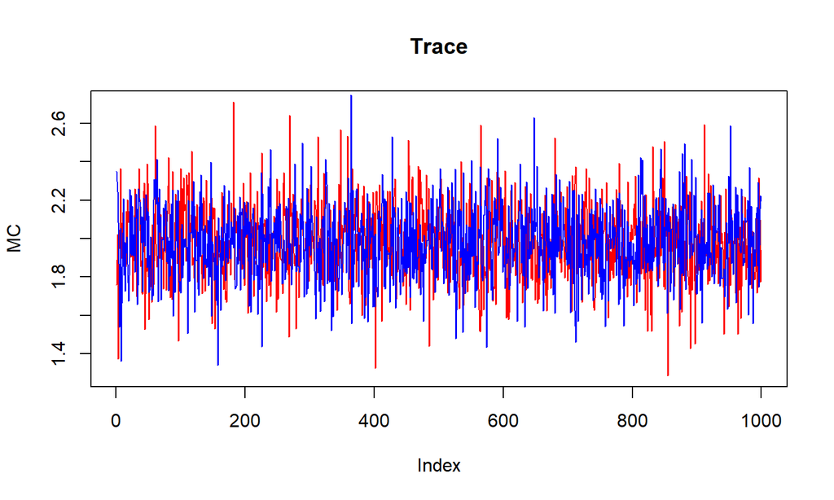

## Multiple Chains for \(\sigma^2\)

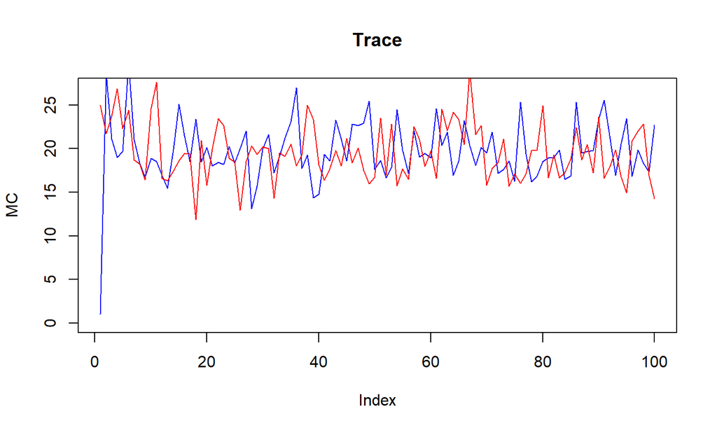

```r
plot(normal_gibbs(y,niter = 100, mu0 = 0, sigma0 = 1)$sigmasq, type= "l", col = "blue",
     main = "Trace", ylab = "MC", ylim = c(0,27))
lines(normal_gibbs(y,niter = 100, mu0 = 0, sigma0 = 25)$sigmasq,col = "red")
```

## Multiple chains

- Histograms are also nice.
- Histogram of samples after burn-in.

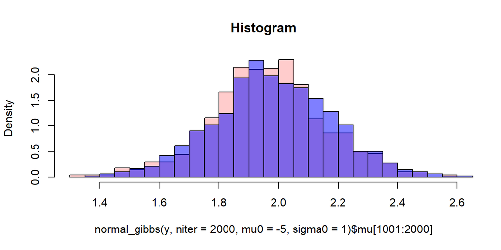

## How many chains?

- How many parallel chains of MCMC should be run ?
- **Experiment yourself**.
- Several long runs (Gelman and Rubin, 1992)
- gives indication of convergence and a sense of statistical security.
- One very long run (Geyer, 1992)
- reaches parts other schemes cannot reach.

## Burn-in?

- Early iterations of \(\theta^1, \ldots, \theta^M\) might reflect starting value \(\theta_0^*\)
- These iterations are called burn-in.
- After the burn-in, we say the chain has ‘converged’.
- In practice, we omit the burn-in from ergodic averages. \[ \bar{h}_{M,N} = \frac{1}{N-M}\sum_{i=M+1}^{N}h(\theta^{(t)}) \]
- Determining \(M\) is called MCMC diagnostics.

## MCMC Diagnostics

- **Must do:**
- Plot the time series for each quantity of interest. (Trace Plot)
- Plot the autocorrelation function. (ACF Plot)

## Diagnostics 1 - Trace plot

1. The trace plot should have rapid up-and-down variation with no long-term trends or drifts.
2. If you split this plot into a few horizontal sections, the trace within any section would not look much different from the trace in any other section.
3. If this has happened, convergence should be fast. Any non-random pattern (Drift/ Periodicity) means slow or no convergence.

## Trace Plot for \(\mu\)

- Seen before
- Plot the quantities at each iteration. It shows the values the parameter took during the runtime of the chain.

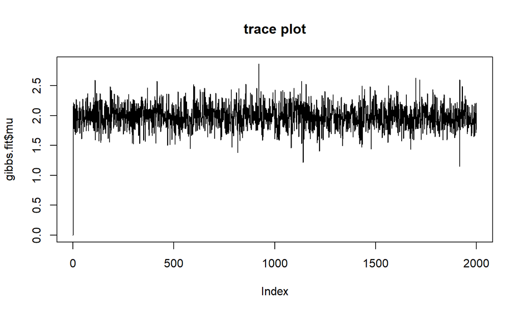

```r
plot(gibbs.fit$mu, type="l",main = "trace plot")
```

## Trace plot for \(\sigma^2\)

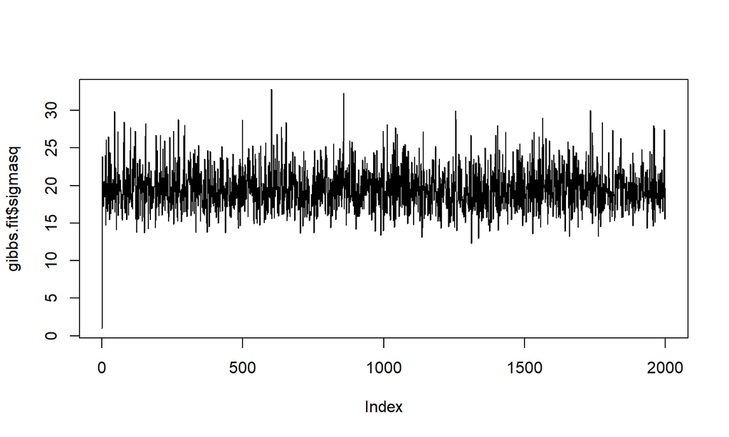

```r
plot(gibbs.fit$sigmasq,type="l")
```

## Autocorrelation

1. High autocorrelation means high nse. Not desirable.
2. If autocorrelation is high then N samples are not giving you N pieces of information about your distribution but fewer than that.
3. The Effective Sample Size (ESS) is one measure of how much information you’re really getting (and is a function of the autocorrelation parameter).

## ACF

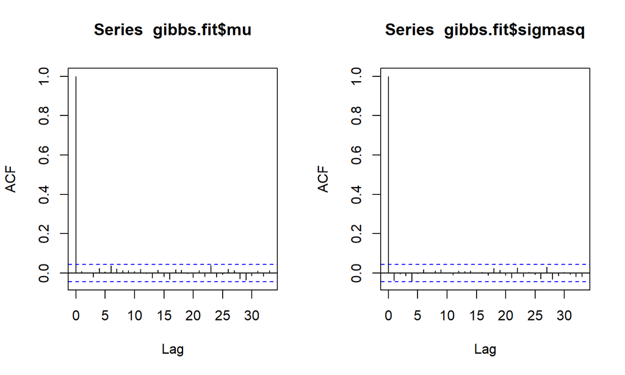

```r
par(mfrow=c(1,2))
acf(gibbs.fit$mu)
acf(gibbs.fit$sigmasq)
```

## Fancier plots

- Look up the R package called `ggmcmc`